# Project3_Deshpande

Nikhil Deshpande

2023-01-29

**GLM and Logistic Regression**

**Introduction**

A family of regression models known as generalized linear models enables us to adapt the linear regression methodology to a wide range of dependent variables. A generalized linear model does not require a continuous or regularly distributed dependent variable (Gero, 2023).

**Three components of a GLM:**

**Random component** – probability distribution of the response variable  
**Systematic component** - specifies the explanatory variables (X1, X2, … Xk) in the model, more specifically their linear combination in creating the so called linear predictor.  
**Link function** - specifies the link between random and systematic components.

**Model Families:**

**Gaussian family** – continuous decimal data with normal distribution like weight, length.

**Binomial** – binary data like 0 and 1, or proportion like survival number vs death number, positive frequency vs negative frequency

**Poisson** – used for counts or frequencies

**Gamma** – used for time data like the time or duration of the occurrence of the event

In contrast to linear regression, which has a limited number of alternative values, the outcome of logistic regression is categorical and has a single possible value, such as “yes” or “no,” or if someone has brown, blue, or green eyes. Classification is the prediction of a label or categorical variable.

**Task 1: College dataset EDA**

Table 1: Statistical Description of College Dataset

|  | vars | n | mean | sd | median | trimmed | mad | min | max | range | skew | kurtosis | se |
| --- | --- | --- | --- | --- | --- | --- | --- | --- | --- | --- | --- | --- | --- |
| Private* | 1 | 777 | 1.727156 | 0.4457084 | 2.0 | 1.783307 | 0.00000 | 1.0 | 2.0 | 1.0 | -1.0179902 | -0.9649328 | 0.0159897 |
| Apps | 2 | 777 | 3001.638353 | 3870.2014844 | 1558.0 | 2193.008026 | 1463.32620 | 81.0 | 48094.0 | 48013.0 | 3.7093849 | 26.5184313 | 138.8427049 |
| Accept | 3 | 777 | 2018.804376 | 2451.1139710 | 1110.0 | 1510.287319 | 1008.16800 | 72.0 | 26330.0 | 26258.0 | 3.4045428 | 18.7526403 | 87.9332239 |
| Enroll | 4 | 777 | 779.972973 | 929.1761901 | 434.0 | 575.953451 | 354.34140 | 35.0 | 6392.0 | 6357.0 | 2.6800857 | 8.7368340 | 33.3340101 |
| Top10perc | 5 | 777 | 27.558559 | 17.6403644 | 23.0 | 25.130016 | 13.34340 | 1.0 | 96.0 | 95.0 | 1.4077650 | 2.1728286 | 0.6328445 |
| Top25perc | 6 | 777 | 55.796654 | 19.8047776 | 54.0 | 55.121990 | 20.75640 | 9.0 | 100.0 | 91.0 | 0.2583399 | -0.5744647 | 0.7104924 |
| F.Undergrad | 7 | 777 | 3699.907336 | 4850.4205309 | 1707.0 | 2574.884430 | 1441.08720 | 139.0 | 31643.0 | 31504.0 | 2.6003876 | 7.6120676 | 174.0078673 |
| P.Undergrad | 8 | 777 | 855.298584 | 1522.4318873 | 353.0 | 536.361156 | 449.22780 | 1.0 | 21836.0 | 21835.0 | 5.6703938 | 54.5249401 | 54.6169397 |
| Outstate | 9 | 777 | 10440.669241 | 4023.0164841 | 9990.0 | 10181.658106 | 4121.62800 | 2340.0 | 21700.0 | 19360.0 | 0.5073133 | -0.4255258 | 144.3249124 |
| Room.Board | 10 | 777 | 4357.526383 | 1096.6964156 | 4200.0 | 4301.704655 | 1005.20280 | 1780.0 | 8124.0 | 6344.0 | 0.4755141 | -0.2012779 | 39.3437648 |
| Books | 11 | 777 | 549.380952 | 165.1053601 | 500.0 | 535.219904 | 148.26000 | 96.0 | 2340.0 | 2244.0 | 3.4715806 | 28.0632782 | 5.9231218 |
| Personal | 12 | 777 | 1340.642214 | 677.0714536 | 1200.0 | 1268.345104 | 593.04000 | 250.0 | 6800.0 | 6550.0 | 1.7357745 | 7.0446395 | 24.2898031 |
| PhD | 13 | 777 | 72.660232 | 16.3281547 | 75.0 | 73.922954 | 17.79120 | 8.0 | 103.0 | 95.0 | -0.7652067 | 0.5442923 | 0.5857693 |
| Terminal | 14 | 777 | 79.702703 | 14.7223585 | 82.0 | 81.102729 | 14.82600 | 24.0 | 100.0 | 76.0 | -0.8133924 | 0.2244365 | 0.5281617 |
| S.F.Ratio | 15 | 777 | 14.089704 | 3.9583491 | 13.6 | 13.935795 | 3.40998 | 2.5 | 39.8 | 37.3 | 0.6648606 | 2.5228017 | 0.1420050 |
| perc.alumni | 16 | 777 | 22.743887 | 12.3918015 | 21.0 | 21.857143 | 13.34340 | 0.0 | 64.0 | 64.0 | 0.6045500 | -0.1113466 | 0.4445534 |
| Expend | 17 | 777 | 9660.171171 | 5221.7684399 | 8377.0 | 8823.704655 | 2730.94920 | 3186.0 | 56233.0 | 53047.0 | 3.4459767 | 18.5875365 | 187.3298993 |
| Grad.Rate | 18 | 777 | 65.463320 | 17.1777099 | 65.0 | 65.601926 | 17.79120 | 10.0 | 118.0 | 108.0 | -0.1133384 | -0.2187930 | 0.6162469 |

Data Source:

US Colleges from the 1995 issue of US News and World Report.

* Categorical Variable

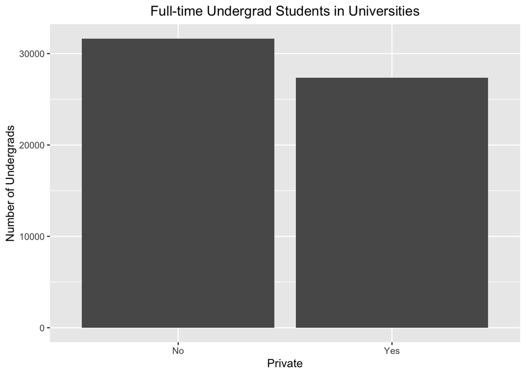

Table 2: Private vs Public Acceptance rate

| Private University Acceptance Rate % | Public University Acceptance Rate % |
| --- | --- |
| 75.5 | 72.7 |

Data Source:

US Colleges from the 1995 issue of US News and World Report.

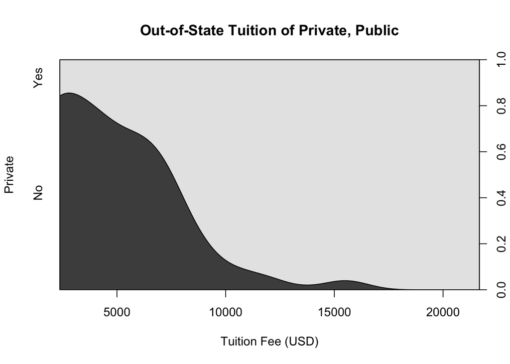

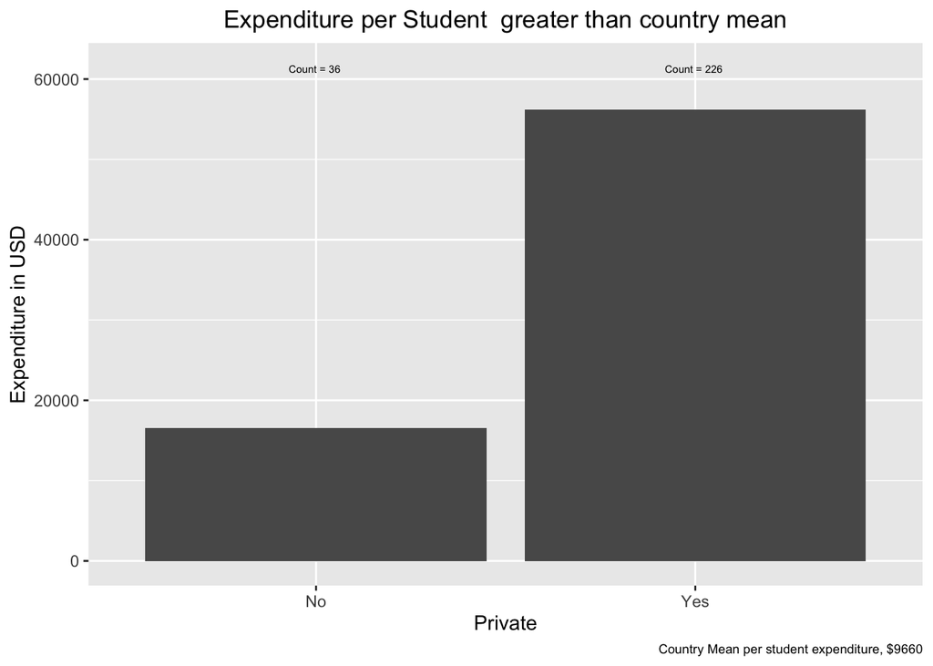

Table 3: Highest per student expenditure(USD) university

|  | Private | Apps | Accept | Enroll | Top10perc | Top25perc | F.Undergrad | P.Undergrad | Outstate | Room.Board | Books | Personal | PhD | Terminal | S.F.Ratio | perc.alumni | Expend | Grad.Rate | Acceptrate |
| --- | --- | --- | --- | --- | --- | --- | --- | --- | --- | --- | --- | --- | --- | --- | --- | --- | --- | --- | --- |
| Johns Hopkins University | Yes | 8474 | 3446 | 911 | 75 | 94 | 3566 | 1569 | 18800 | 6740 | 500 | 1040 | 96 | 97 | 3.3 | 38 | 56233 | 90 | 0.4066557 |

Data Source:

US Colleges from the 1995 issue of US News and World Report.

Table 4: Private vs Public Student:Faculty

| Private University Student to Faculty Ratio | Public University Student to Faculty Ratio |
| --- | --- |
| 17.14 | 12.95 |

Data Source:

US Colleges from the 1995 issue of US News and World Report.

Table 5: Best fit Model

| Resid. Df | Resid. Dev | Df | Deviance |
| --- | --- | --- | --- |
| 773 | 541.1257 | NA | NA |
| 773 | 482.9046 | 0 | 58.22114 |

Test fit:

Test 1: Private ~ S.F.Ratio + Grad.Rate + Outstate and  
Test 2: Private ~ Top10perc + F.Undergrad + PhD

Table 6: AIC Best fit Model

|  | df | AIC |
| --- | --- | --- |
| testfit | 4 | 549.1257 |
| testfit2 | 4 | 490.9046 |

Test fit:

Test 1: Private ~ S.F.Ratio + Grad.Rate + Outstate and  
Test 2: Private ~ Top10perc + F.Undergrad + PhD

**Observation:**

The College dataset, sourced from the 1995 issue of US News and World Report, contains information on various attributes of American colleges and universities. The dataset includes variables such as the school’s name, private/public status, enrollment size, percent of students from Top 10 and 25 of high school class, acceptance rate, and expenditures per student. The dataset can be used to explore relationships between different attributes, such as the relationship between a school’s expenditure per student and percentage of students from top 10 or 25 high school class. Additionally, statistical techniques such as regression analysis can be used to identify the most significant predictors of a school’s overall success, as determined by the US News and World Report. This dataset can be used to understand the trends of colleges in 1995 and can also be used to compare with recent data. Furthermore, it can help to understand how the factors affecting the success of colleges and universities have changed over time.

After a thoughtful consideration, I have decided to consider Student:Faculty ratio, Outstate, Grad Rate, percentage of students from Top 10 high school, and Full time undergraduate to measure the success of the universities. Model 1 measures the correlation of Private to Student:Faculty ratio, Outstate, Grad Rate and Model 2 percentage of students from Top 10 high school, and Full time undergraduate, Model 2 is best fit. This model is selected based on preliminary analysis. I would be modeling different regression models in the next tasks.

**Task 2:**

**Observation:**

In this task, I would be splitting the College dataset into two parts: a training set(70%) and a test set(30%). The training set is used to train the model, while the test set is used to evaluate the model’s performance.  
The main reason for doing a train and test split is to evaluate the performance of a machine learning model. A model that performs well on the training set is not necessarily a good indicator of how well the model will perform on unseen data.

When a model is trained and tested on the same data, it can result in overfitting, where the model performs well on the training data but poorly on new unseen data. By splitting the data into a training set and a test set, we can evaluate the model’s performance on unseen data and get a better idea of how well the model is likely to perform on new, unseen data.

Another reason for doing a train and test split is to be able to compare the performance of different models. By training and testing several models on the same data, we can compare their performance and select the best model.

In addition, train and test split help in finding the optimal parameters of the model by tuning the hyperparameters using the train set and test it on test set.

Once the dataset has been split into training and test sets, the model can be trained on the training set using a function such as lm()-Linear Regression or glm()- Logistic Regression. Then, the model’s performance can be evaluated on the test set using function ConfusionMatrix().

In summary, train and test split is an important step in the machine learning process as it allows us to evaluate the performance of a model, compare the performance of different models, and ensure that the model is generalizing well to new, unseen data.

**Task 3:**

```
##
## Call:
## glm(formula = Private ~ ., family = binomial(link = "logit"),
##     data = traindata)
##
## Deviance Residuals:
##     Min       1Q   Median       3Q      Max
## -3.3564  -0.0070   0.0396   0.1596   3.0606
##
## Coefficients:
##               Estimate Std. Error z value Pr(>|z|)
## (Intercept)  5.493e-01  3.112e+00   0.177  0.85988
## Apps        -8.661e-04  4.930e-04  -1.757  0.07893 .
## Accept       1.465e-03  7.582e-04   1.933  0.05328 .
## Enroll       9.076e-05  1.168e-03   0.078  0.93808
## Top10perc    1.542e-02  3.607e-02   0.428  0.66891
## Top25perc   -5.867e-04  2.430e-02  -0.024  0.98074
## F.Undergrad -8.399e-04  2.879e-04  -2.918  0.00353 **
## P.Undergrad  2.247e-04  1.904e-04   1.181  0.23775
## Outstate     9.145e-04  1.617e-04   5.654 1.57e-08 ***
## Room.Board  -4.767e-04  3.529e-04  -1.351  0.17673
## Books        6.782e-04  1.511e-03   0.449  0.65358
## Personal    -1.564e-04  3.275e-04  -0.477  0.63301
## PhD         -3.799e-02  3.604e-02  -1.054  0.29183
## Terminal    -4.040e-02  3.442e-02  -1.174  0.24047
## S.F.Ratio    3.935e-03  8.349e-02   0.047  0.96241
## perc.alumni  4.128e-02  2.692e-02   1.533  0.12522
## Expend       2.253e-04  1.480e-04   1.522  0.12798
## Grad.Rate    1.496e-02  1.486e-02   1.007  0.31413
## Acceptrate  -1.605e+00  2.347e+00  -0.684  0.49417
## ---
## Signif. codes:  0 '***' 0.001 '**' 0.01 '*' 0.05 '.' 0.1 ' ' 1
##
## (Dispersion parameter for binomial family taken to be 1)
##
##     Null deviance: 639.40  on 544  degrees of freedom
## Residual deviance: 154.73  on 526  degrees of freedom
## AIC: 192.73
##
## Number of Fisher Scoring iterations: 8
```

Table 7: Coefficinent of Model

|  | Coefficient of Model |
| --- | --- |
| (Intercept) | 0.0148729 |
| F.Undergrad | 0.9992869 |
| perc.alumni | 1.0323057 |
| Outstate | 1.0008423 |

Test fit:

Test 1: Private ~ F.Undergrad + perc.alumni + Outstate

**Observation:**

GLMs are a type of statistical model that extend the generalized linear model framework to allow for response variables that have error distributions other than a normal distribution. glm() allows for fitting a wide range of models, including linear regression, logistic regression, Poisson regression, and others. It can handle both continuous and categorical predictor variables, and can include interactions and non-linear terms.

**Task 4:**

Table 8: Predicated Probability of Train Data

|  | Probabilities |
| --- | --- |
| Adelphi University | 0.9912108 |
| Adrian College | 0.9958409 |
| Agnes Scott College | 0.9994559 |
| Alaska Pacific University | 0.8852125 |
| Albertson College | 0.9991105 |
| Albertus Magnus College | 0.9994532 |
| Albion College | 0.9994511 |
| Albright College | 0.9998714 |
| Alderson-Broaddus College | 0.9891433 |
| Alfred University | 0.9999176 |

Probability:

Predict model ran on train data shows first 10 observations

```
## Confusion Matrix and Statistics
##
##           Reference
## Prediction  No Yes
##        No  130  16
##        Yes  19 380
##
##                Accuracy : 0.9358
##                  95% CI : (0.9118, 0.9549)
##     No Information Rate : 0.7266
##     P-Value [Acc > NIR] : <2e-16
##
##                   Kappa : 0.8373
##
##  Mcnemar's Test P-Value : 0.7353
##
##             Sensitivity : 0.9596
##             Specificity : 0.8725
##          Pos Pred Value : 0.9524
##          Neg Pred Value : 0.8904
##              Prevalence : 0.7266
##          Detection Rate : 0.6972
##    Detection Prevalence : 0.7321
##       Balanced Accuracy : 0.9160
##
##        'Positive' Class : Yes
##
```

**Observation:**

Predict() function is used to make predictions for new data using a fitted model. The predictions can be used for a variety of purposes, such as:  
**Model evaluation**: By comparing the predicted values to the actual values for a set of new data, we can evaluate the performance of the model and determine how well it is able to generalize to new data.  
**Model comparison**: By comparing the predicted values from different models, we can determine which model is the best fit for the data.  
**Forecasting**: We can use the predict function to forecast future values of a response variable based on the model that has been fit to historical data.  
**Understanding model behavior**: The predict function can also be used to understand how the model behaves for different input values. This can be useful for understanding the relationship between predictor variables and the response variable.  
**Decision making**: In some cases, the predictions can be used to make decisions. For example, a model that predicts the probability of universities churn can be used to identify Public or Private and take action to retain them. Overall, predict function is a key function in data modeling as it allows to test the model on unseen data and evaluate its performance.

Furthermore, as.factor() is used on the output of the predict() to change probability more than 0.5 to Yes and others to No. This arrangement would we used to make data ConfusionMatrix() compatible.

ConfusionMatrix() is used to create a confusion matrix, which is a table that is used to evaluate the performance of a classification model. The matrix is created by comparing the predicted class labels to the actual class labels for a set of test data.  
The confusion matrix has four main elements: **true positives (TP), false positives (FP), true negatives (TN), and false negatives (FN).**

Type 1 Error: False Positives (FP)  
Type 2 Error: False Negatives (FN)

The confusion matrix is useful for understanding the performance of a classification model in terms of precision, recall, accuracy, and specificity.  
ConfusionMatrix() function can be used with various classification models, such as logistic regression, decision trees, random forests, etc. It can also be used with multiclass classification problems. It is an important step in evaluating the performance of a model and helps in identifying any errors or bias present in the model.

In general, false positives and false negatives can have different consequences and it is important to consider the specific context of the analysis when determining which misclassification is more damaging. As the goal of the analysis is to identify schools with Full time undergrads, percentage of alumni who donate and out-of-state tuition, a false negative (failing to identify a school with high out-of-state tuition) might be more damaging than a false positive (identifying a school as having high out-of-state tuition when it does not). On the other hand, if the goal of the analysis is to identify schools with low out-of-state tuition per student, a false positive might be more damaging.

By counting the number of observations in each of these cells, we can calculate various metrics such as accuracy, precision, recall, and F1-score.

Accuracy = (TP+TN)/(TP+TN+FP+FN)  
Precision = TP/(TP+FP)  
Recall = TP/(TP+FN)  
F1-score = 2PrecisionRecall/(Precision+Recall)

**Task 5:Interpreting ConfusionMatrix()**

```
##          Sensitivity          Specificity       Pos Pred Value
##            0.9595960            0.8724832            0.9523810
##       Neg Pred Value            Precision               Recall
##            0.8904110            0.9523810            0.9595960
##                   F1           Prevalence       Detection Rate
##            0.9559748            0.7266055            0.6972477
## Detection Prevalence    Balanced Accuracy
##            0.7321101            0.9160396
```

```
##       Accuracy          Kappa  AccuracyLower  AccuracyUpper   AccuracyNull
##   9.357798e-01   8.373370e-01   9.118140e-01   9.548642e-01   7.266055e-01
## AccuracyPValue  McnemarPValue
##   8.161411e-36   7.353167e-01
```

**Observation:**

Type 1 Error: False Positives (FP)  
Type 2 Error: False Negatives (FN)

**Task 6:**

Table 9: Predicated Probabilites of Test Data

|  | Probabilities for Test data |
| --- | --- |
| Abilene Christian University | 0.5936725 |
| Amherst College | 0.9999983 |
| Antioch University | 0.9999194 |
| Appalachian State University | 0.0059170 |
| Aquinas College | 0.9941216 |
| Arkansas Tech University | 0.0239912 |
| Assumption College | 0.9964255 |
| Barat College | 0.9913350 |
| Barnard College | 0.9999702 |
| Barry University | 0.9873203 |

Probability:

Predict model ran on test data shows first 10 observations

```
## Confusion Matrix and Statistics
##
##           Reference
## Prediction  No Yes
##        No   58   9
##        Yes   5 160
##
##                Accuracy : 0.9397
##                  95% CI : (0.9008, 0.9666)
##     No Information Rate : 0.7284
##     P-Value [Acc > NIR] : <2e-16
##
##                   Kappa : 0.8504
##
##  Mcnemar's Test P-Value : 0.4227
##
##             Sensitivity : 0.9467
##             Specificity : 0.9206
##          Pos Pred Value : 0.9697
##          Neg Pred Value : 0.8657
##              Prevalence : 0.7284
##          Detection Rate : 0.6897
##    Detection Prevalence : 0.7112
##       Balanced Accuracy : 0.9337
##
##        'Positive' Class : Yes
##
```

Table 10: Error Probability in the model

| Error Probability |
| --- |
| 0.0419 |

Error Probability:

Private ~ F.Undergrad + perc.alumni + Outstate

**Observation:**

Type 1 Error: False Positives (FP)  
Type 2 Error: False Negatives (FN)

**Task 7:**

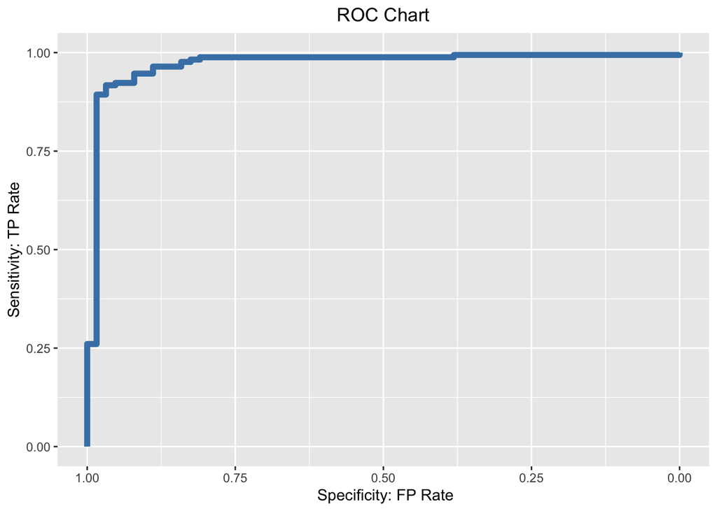

**Observation:**

The roc() function is used to create a receiver operating characteristic (ROC) curve, which is a graphical representation of the performance of a binary classifier system as the discrimination threshold is varied. The ROC curve is created by plotting the true positive rate (sensitivity) against the false positive rate (1-specificity) at various threshold settings. The area under the ROC curve (AUC) is a measure of the overall performance of the classifier, with a value of 1 indicating perfect classification and a value of 0.5 indicating a classifier that performs no better than chance.

**Task 8:**

```
## Area under the curve: 0.9714
```

**Observation:**

The ROC chart shows the model is well suited to make predictions accurately as AOC that is area under the curve is 97%.

**Conclusion:**

In this project, we have tested glm() to test logistic regression on Categorical variable Private. Private have Yes,No values for university category. The glm() provided the best suited model by running on the dataset and we have selected three independent variable to test and train the dataset to predict private and public university based upon the enrolled Full time undergrads, Percentage of Alumni who donate and Out-of-State tuition fee. The model shows overall 94% accuracy and error labelling private as public is nearly 4%.

**Reference:**

Bluman, A. (2014). *Elementary statistics: A step by step approach*. McGraw-Hill Education.  
Gero, E. (2023). *ALY6015_Module3_Logistic_Regression*[Lecture recording]. Canvas@Northeastern University.https://canvas.northeastern.edu/  
Kabacoff, R. (2015). *R in Action*. Manning Publications Co.  
Zach. (2020). *How to Calculate AUC (Area Under Curve) in R*. Statology. https://www.statology.org/auc-in-r/

**Appendix**

An R Markdown file has been attached to this report. The name of the file is Project3_Deshpande.Rmd